# Red Wine by Fillarry Susanto

This report explores a dataset containing the chemical content of 1599 red wines and the resulting evaluation of their tastes according to wine experts, scaled from 0 to 10.

# Univariate Plots Section

```
## [1] 1599   13
```

```
## 'data.frame':    1599 obs. of  13 variables:
##  $ X                   : int  1 2 3 4 5 6 7 8 9 10 ...
##  $ fixed.acidity       : num  7.4 7.8 7.8 11.2 7.4 7.4 7.9 7.3 7.8 7.5 ...
##  $ volatile.acidity    : num  0.7 0.88 0.76 0.28 0.7 0.66 0.6 0.65 0.58 0.5 ...
##  $ citric.acid         : num  0 0 0.04 0.56 0 0 0.06 0 0.02 0.36 ...
##  $ residual.sugar      : num  1.9 2.6 2.3 1.9 1.9 1.8 1.6 1.2 2 6.1 ...
##  $ chlorides           : num  0.076 0.098 0.092 0.075 0.076 0.075 0.069 0.065 0.073 0.071 ...
##  $ free.sulfur.dioxide : num  11 25 15 17 11 13 15 15 9 17 ...
##  $ total.sulfur.dioxide: num  34 67 54 60 34 40 59 21 18 102 ...
##  $ density             : num  0.998 0.997 0.997 0.998 0.998 ...
##  $ pH                  : num  3.51 3.2 3.26 3.16 3.51 3.51 3.3 3.39 3.36 3.35 ...
##  $ sulphates           : num  0.56 0.68 0.65 0.58 0.56 0.56 0.46 0.47 0.57 0.8 ...
##  $ alcohol             : num  9.4 9.8 9.8 9.8 9.4 9.4 9.4 10 9.5 10.5 ...
##  $ quality             : int  5 5 5 6 5 5 5 7 7 5 ...
```

```
##        X          fixed.acidity   volatile.acidity  citric.acid
##  Min.   :   1.0   Min.   : 4.60   Min.   :0.1200   Min.   :0.000
##  1st Qu.: 400.5   1st Qu.: 7.10   1st Qu.:0.3900   1st Qu.:0.090
##  Median : 800.0   Median : 7.90   Median :0.5200   Median :0.260
##  Mean   : 800.0   Mean   : 8.32   Mean   :0.5278   Mean   :0.271
##  3rd Qu.:1199.5   3rd Qu.: 9.20   3rd Qu.:0.6400   3rd Qu.:0.420
##  Max.   :1599.0   Max.   :15.90   Max.   :1.5800   Max.   :1.000
##  residual.sugar     chlorides       free.sulfur.dioxide
##  Min.   : 0.900   Min.   :0.01200   Min.   : 1.00
##  1st Qu.: 1.900   1st Qu.:0.07000   1st Qu.: 7.00
##  Median : 2.200   Median :0.07900   Median :14.00
##  Mean   : 2.539   Mean   :0.08747   Mean   :15.87
##  3rd Qu.: 2.600   3rd Qu.:0.09000   3rd Qu.:21.00
##  Max.   :15.500   Max.   :0.61100   Max.   :72.00
##  total.sulfur.dioxide    density             pH          sulphates
##  Min.   :  6.00       Min.   :0.9901   Min.   :2.740   Min.   :0.3300
##  1st Qu.: 22.00       1st Qu.:0.9956   1st Qu.:3.210   1st Qu.:0.5500
##  Median : 38.00       Median :0.9968   Median :3.310   Median :0.6200
##  Mean   : 46.47       Mean   :0.9967   Mean   :3.311   Mean   :0.6581
##  3rd Qu.: 62.00       3rd Qu.:0.9978   3rd Qu.:3.400   3rd Qu.:0.7300
##  Max.   :289.00       Max.   :1.0037   Max.   :4.010   Max.   :2.0000
##     alcohol         quality
##  Min.   : 8.40   Min.   :3.000
##  1st Qu.: 9.50   1st Qu.:5.000
##  Median :10.20   Median :6.000
##  Mean   :10.42   Mean   :5.636
##  3rd Qu.:11.10   3rd Qu.:6.000
##  Max.   :14.90   Max.   :8.000
```

The Red Wine data ste contains 1599 observations with 13 variables. There are no sweet red wine as max of residual sugar is 15.5 g/L where it is considered sweet only when sugar > 45 g/L.

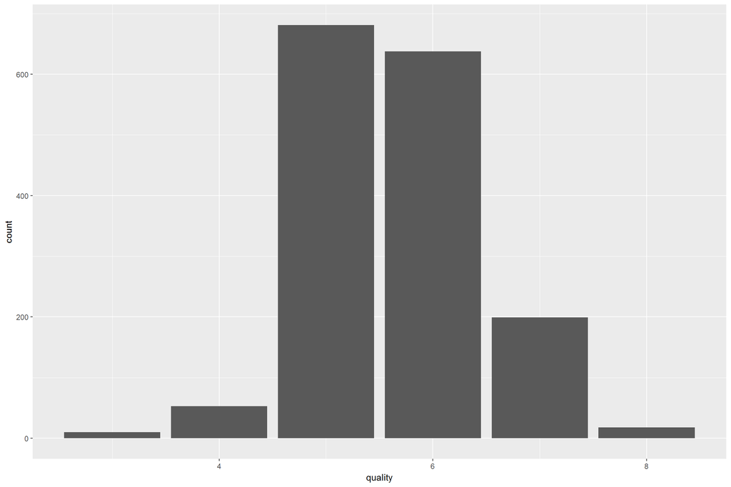

The quality of red wine seems to have a normal distribution with a maximum number at quality=5 and they have discrete values. It seeems most wine are just average while there are a few that is really bad and a few that are really good. None of them is better than 8 though (I guess no wine is perfect). Let us now look at the different distribution of the chemical content, starting with the different acids.

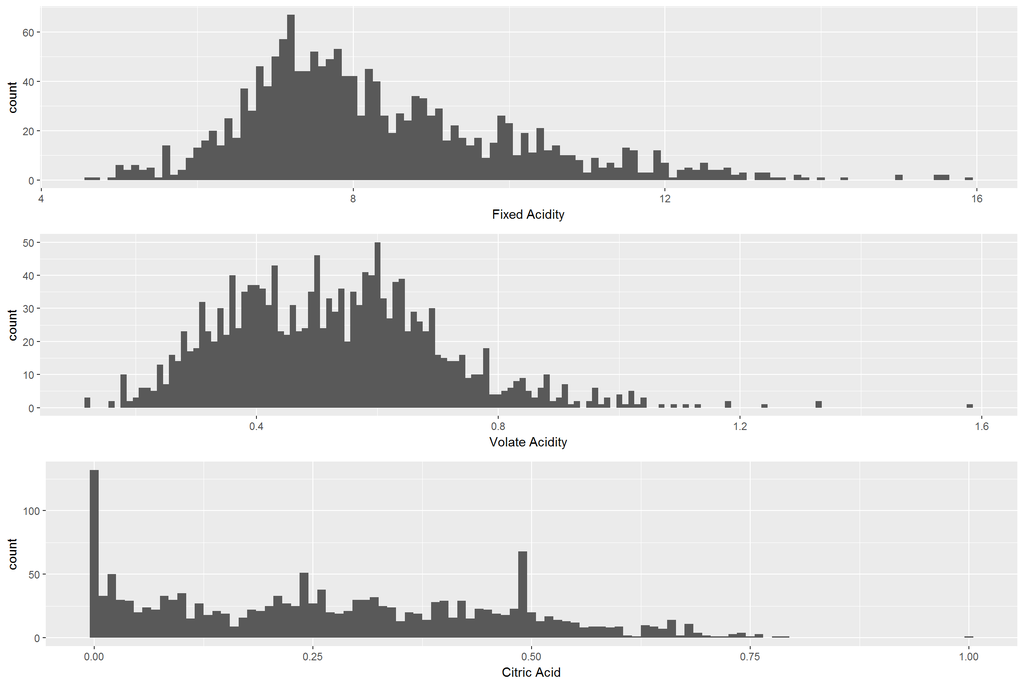

The fixed, volatile and citric acid concentrations follow a slightly positively skewed distribution with a long tail. Also, there are a lot of the wine that do not have any citric acid content in it (around 10% does not have citric acid. Citric acid is known to add fresh flavor to the wine. I wonder if having the freshness increases the quality of wine.

```
##  citric.acid
##  Mode :logical
##  FALSE:1467
##  TRUE :132
```

Volatile acid consists of mainly acetic acid which can lead to unpleasant vinegary taste, I wonder what is the threshold amount of volatile acid where the quality of wine starts to drop. Now, let’s look at the statistics of fixed acidity, volatile acidity and citric acid in that order shown below:

```
##    Min. 1st Qu.  Median    Mean 3rd Qu.    Max.
##    4.60    7.10    7.90    8.32    9.20   15.90
```

```
##    Min. 1st Qu.  Median    Mean 3rd Qu.    Max.
##  0.1200  0.3900  0.5200  0.5278  0.6400  1.5800
```

```
##    Min. 1st Qu.  Median    Mean 3rd Qu.    Max.
##   0.000   0.090   0.260   0.271   0.420   1.000
```

Next thing to look at is the sulfur content.

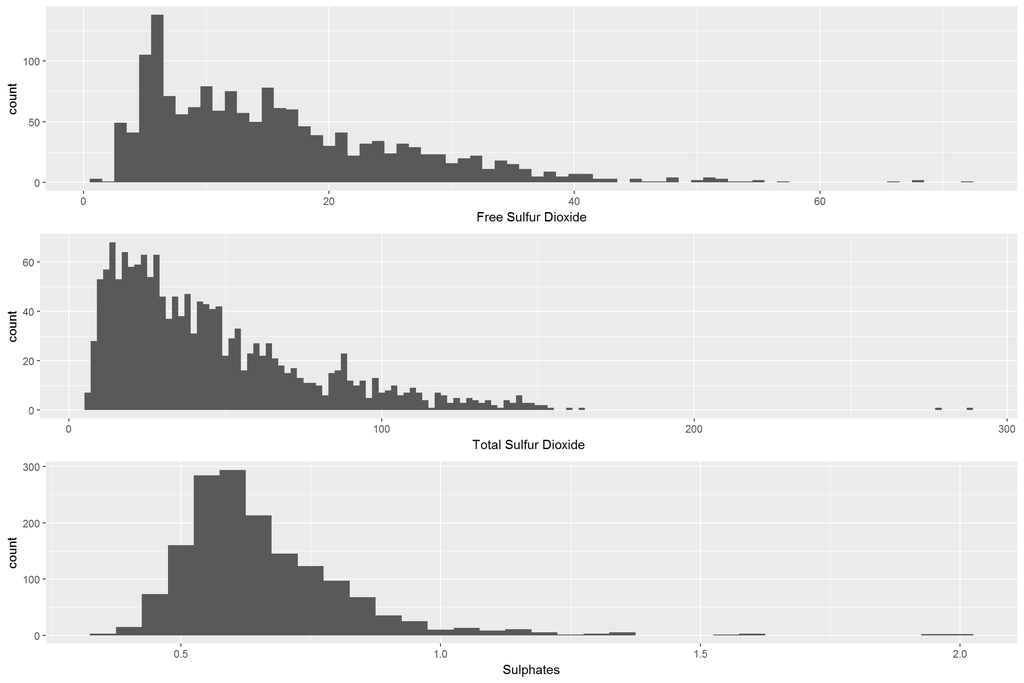

All the sulfur-related chemical content seems to have a positively skewed distribution. Summary of free sulfur dioxide, total sulfur dioxide and sulphates in that order is below:

```
##    Min. 1st Qu.  Median    Mean 3rd Qu.    Max.
##    1.00    7.00   14.00   15.87   21.00   72.00
```

```
##    Min. 1st Qu.  Median    Mean 3rd Qu.    Max.
##    6.00   22.00   38.00   46.47   62.00  289.00
```

```
##    Min. 1st Qu.  Median    Mean 3rd Qu.    Max.
##  0.3300  0.5500  0.6200  0.6581  0.7300  2.0000
```

Again, it can be seen that max value is much higher than the mean or 3rd quartile, which is a typical characteristic of a long tail distribution with some outliers. A log-log transformation is needed to be able to get a better look of the distribution, except for sulphates since it has a tighter distribution.

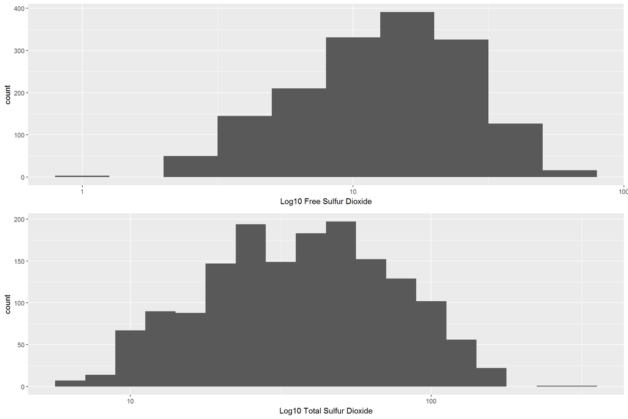

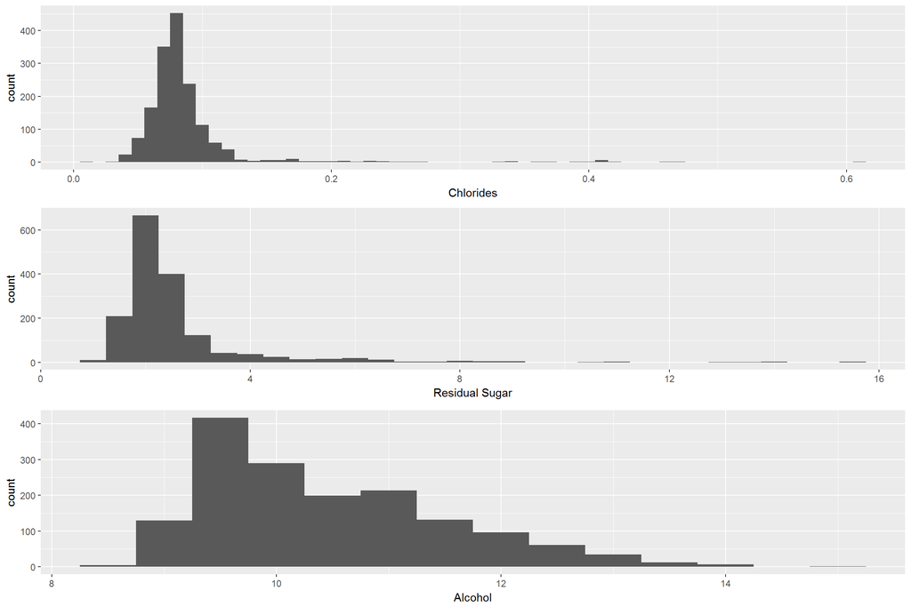

The chlorides and residual sugar follow a tight normal distribution with some outliers while the alcohol seems to have a longer tail and more positively skewed.

I am interested to look at the outliers for both chlorides and residual sugar

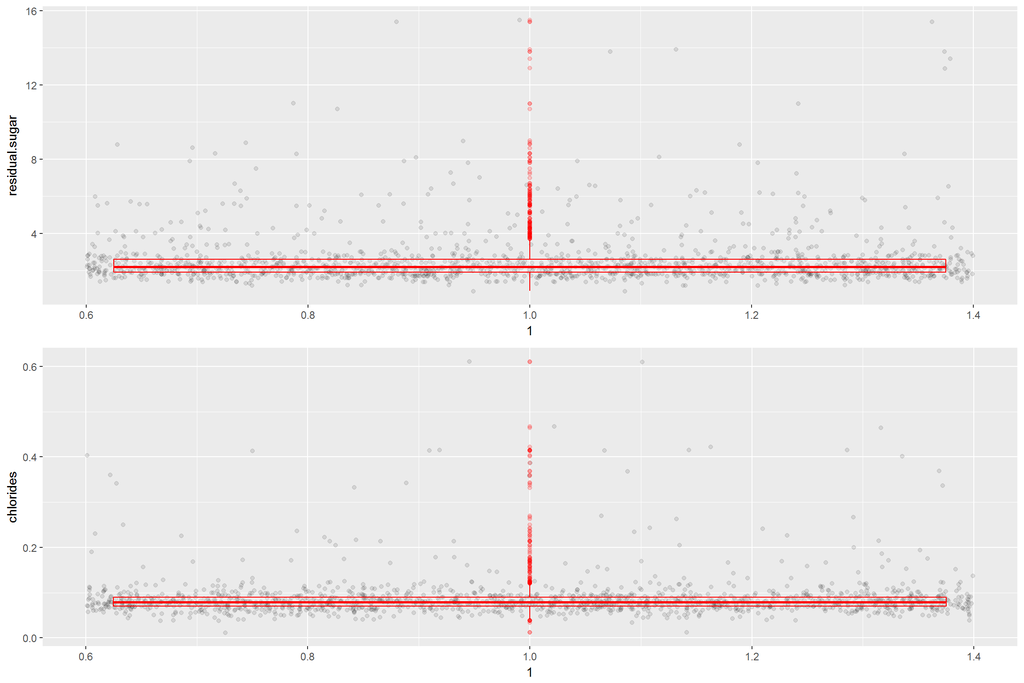

There are a considerable amount of outliers shown in the box plot but with the same reasoning, I am going to keep all the outliers for analysis. Lastly, we are going to look at the pH and density distribution.

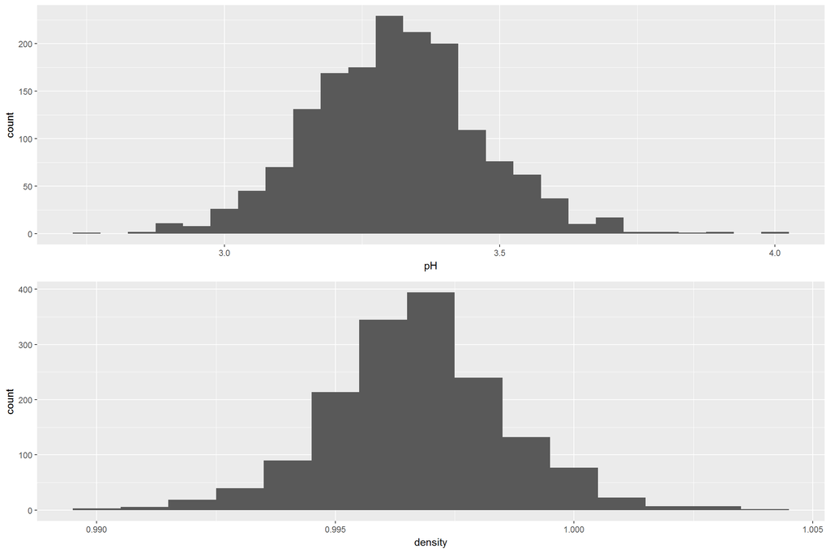

All the wines are acidic with most of them having pH of 3-3.5. The density distribution of the wine is very tight and probably very dependent on the alcohol content of the wine. The only way that density is more than water is if the alcohol contains a lot of solids dissolved.

Let us begin to take subset of the wine data set and see the quality.

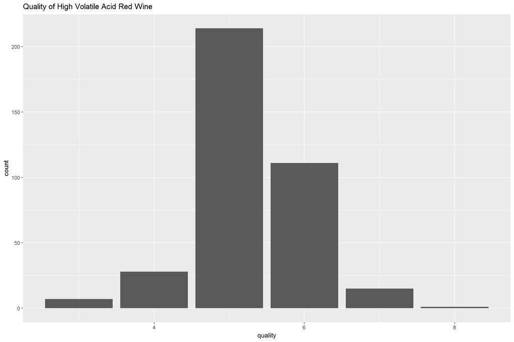

For higher volatility acid, it seems that it does not affect the quality of wine as significantly since there is still a range of distribution but there seems to be much more of quality 5 than 6 compared to when plotting the whole data set.

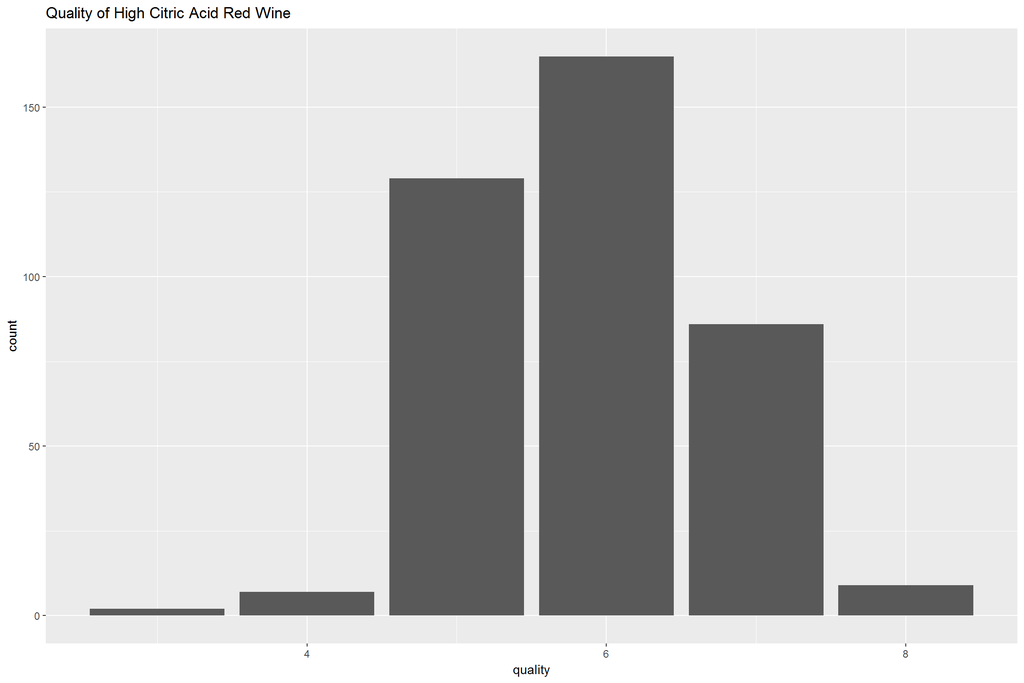

Seems like higher citric acid content results in higher quality red wine as there are more higher quality ones compared to as a whole.

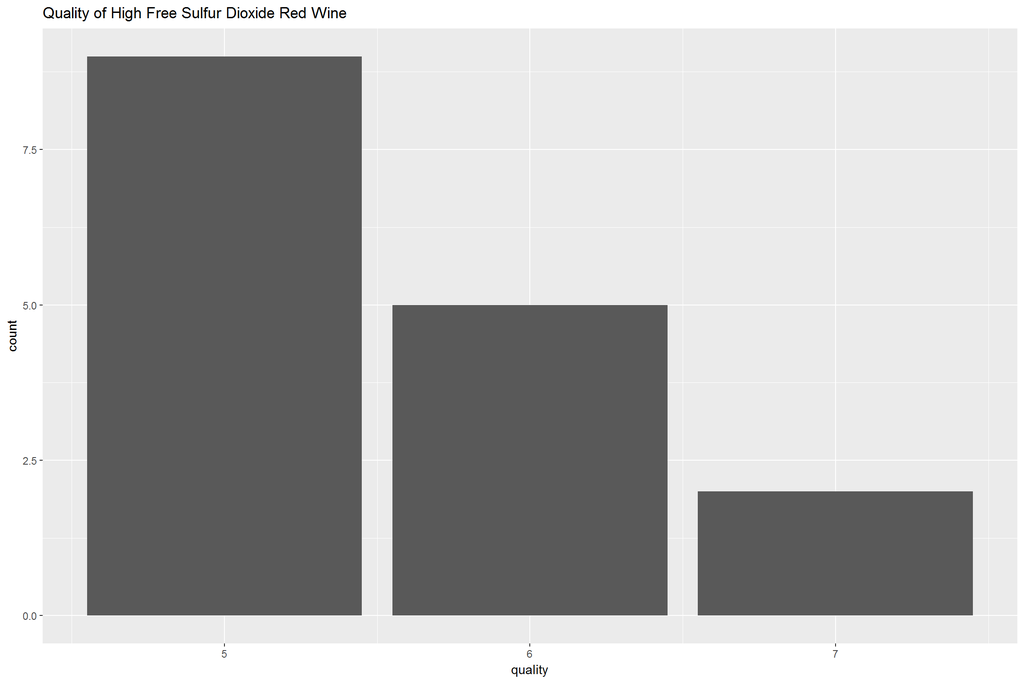

Surprisingly, it is not as bad as I expected it to be as usually sulfur smell and starts to become apparent over 50 ppm.

Last thing, I want to create a new variable to transform the wine quality into categorical group with 0-4 as bad, 5-6 as average and 7-10 as good.

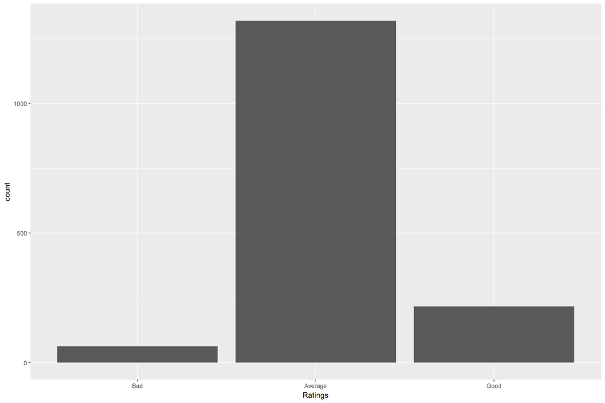

Most wines are average rated by the wine experts. There are more good wine than bad wine.

# Univariate Analysis

### What is the structure of your dataset?

My dataset contains 1599 observation with 11 different features that influences the quality of the wine. There are 10 features (citric acid, free sulfur dioxide , pH, fixed acidity, residual sugar, total sulfur dioxide. sulphates, volatile acidity, chlorides and alcohol) that describes the chemical content and 1 (density) that describes the physical property.

Quality is an ordered factor ranging from 0 (worst) to 10 (best)

Some observations: - Most red wines are either quality 5 or 6. - Most of the chemical components have a normal distribution except for the sulfur related ones and alcohol that has more of a positive skewed distribution - There are a considerable amount of red wine that has no citric acid content (around 10%) - The density and pH of alcohol follow a pretty tight distribution with most pH between 3-3.5 and most density between 0.992 g/cm3 to 1.002 g/cm3.

### What is/are the main feature(s) of interest in your dataset?

The main feature of this dataset is the quality of the red wine judged by experts and how this different chemical components influences the rating given by these experts. My guess is there are certain thresholds of each components that results in a better quality of wine.

### What other features in the dataset do you think will help support your investigation into your feature(s) of interest?

Acidity, alcohol content, sulfur related components content and chlorides seems to be components that have a strong effect on how red wine will taste and smell which is strongly related to the quality of the dataset.

### Did you create any new variables from existing variables in the dataset?

Yes, I created an ordered rating for the quality of wine with 0-4 as Bad, 5-6 as Average and 7-10 as Good.

### Of the features you investigated, were there any unusual distributions? Did you perform any operations on the data to tidy, adjust, or change the form of the data? If so, why did you do this?

As I have mentioned before, most of the cheical components and density follows a normal distribution. But interestingly, citric acid, alcohol and sulfur related components have a more positively skewed distribution. In order to know more about the distribution, I performed a log10 transformation to understand the distribution more and the log10 transformation follows a normal distribution.

# Bivariate Plots Section

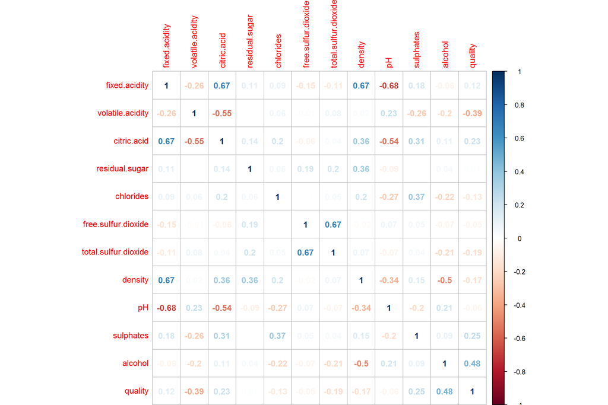

From the plot, there are several variables that seems to be correlated. 1. Fixed acidity seems to correlate with citric acid, density and pH 2. For quality, alcohol, volatile acidity, citric acid and sulphate seems to have some correlation. 3. Some correlation between density and alcohol content

since we are interested mainly on red wine quality, let us look at the variables that seems to have some correlation with red wine.

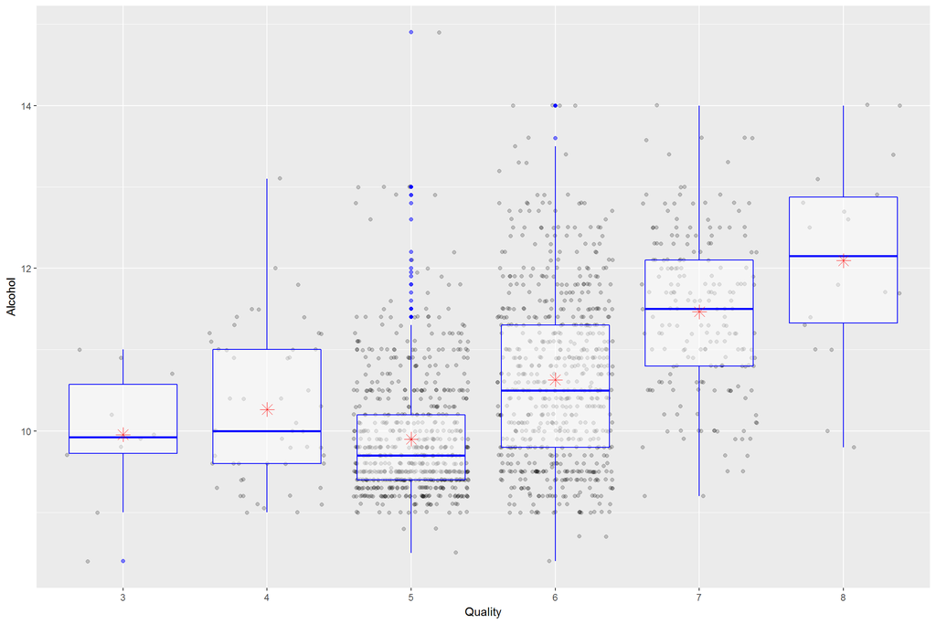

There seems to be some positive relationship between alcohol content and quality. The box plot means help guide the eye to see the positive trend. From the correlation plot, R2 is 0.48. Quite expected as higher alcohol content might imply that the wine was made from better quality grapes.

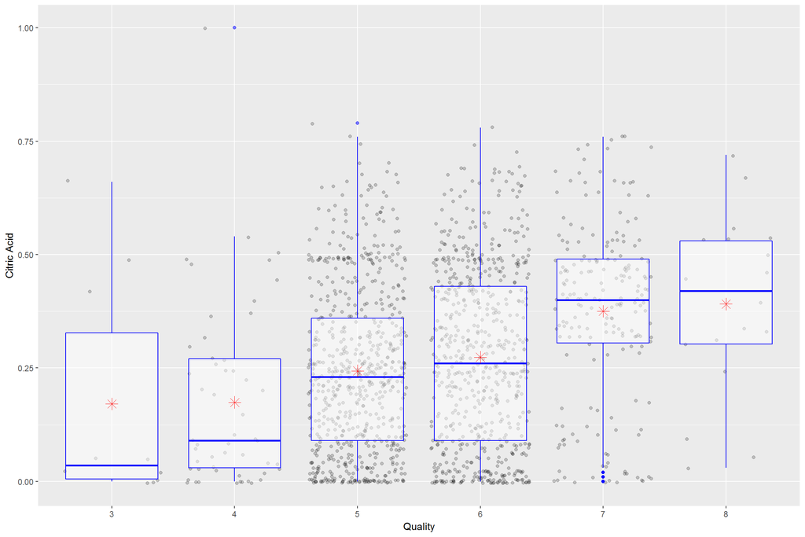

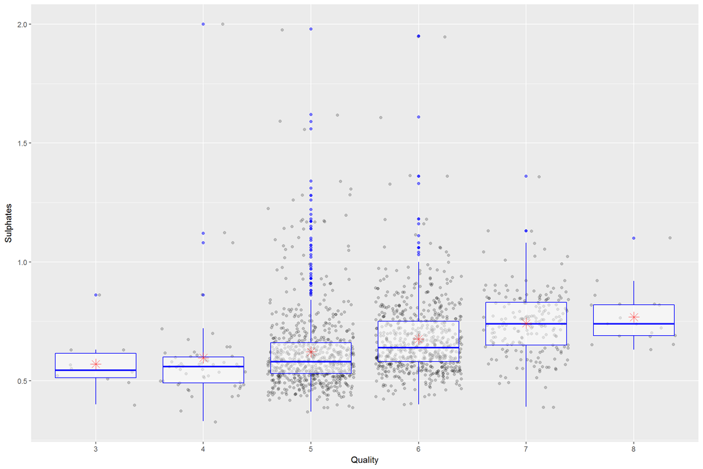

Slight positive trend can be seen between sulphates concentration and quality with R2 of 0.25. Interesting correlation plot shows trend with sulphates but not free sulfur dioxide or total sulfur dioxide which serves as similar purpose. Sulphates might also contribute to flavor.

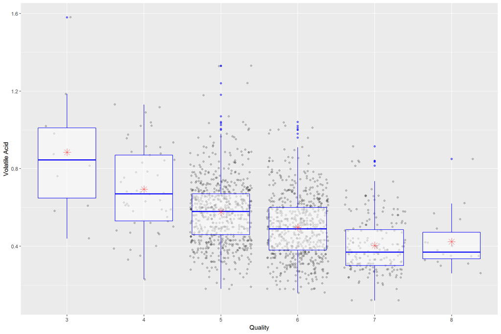

Looking at the plots above, there seems to be some trend even though there is a lot of scatter.

Let’s look at other features to see if they have any correlation with each other.

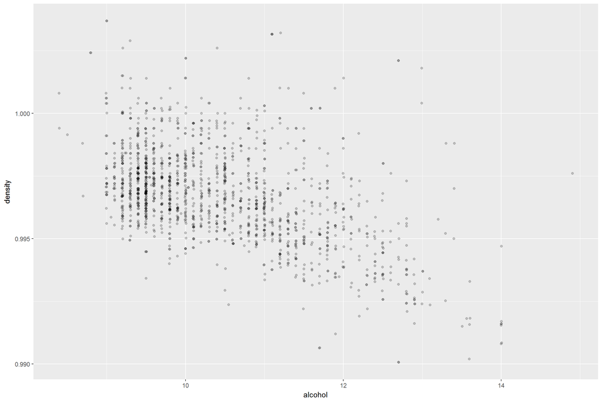

The higher the alcohol content, the lower the density. This makes sense since alcohol is less dense than water (majority of wine) and most of other components of the wine.

The total acid in the wine is defined as the sum of fixed acidity, volatile acidity and citric acid. Let’s make some plots with total acid.

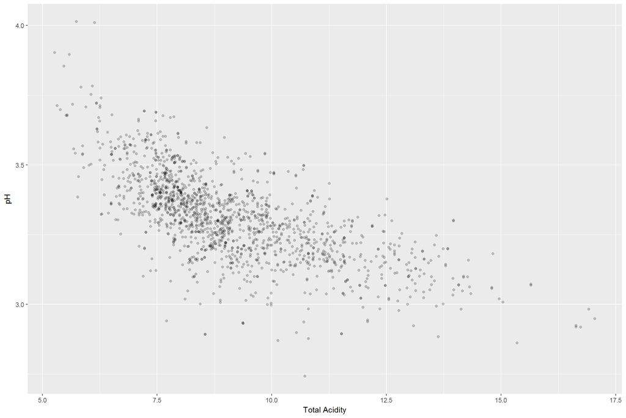

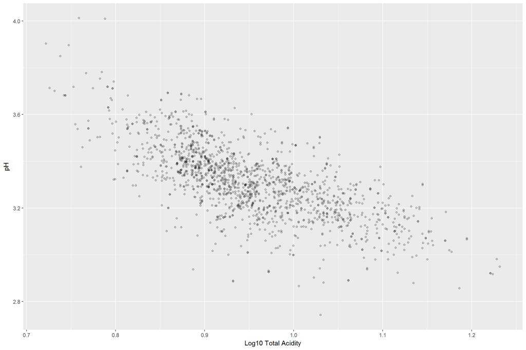

By definition, pH is the -log10 of H+ ions concentration and H+ ions are produced by acid so this plot makes sense.

Now let’s look at the variables in regards to the red wine ratings using box plots.

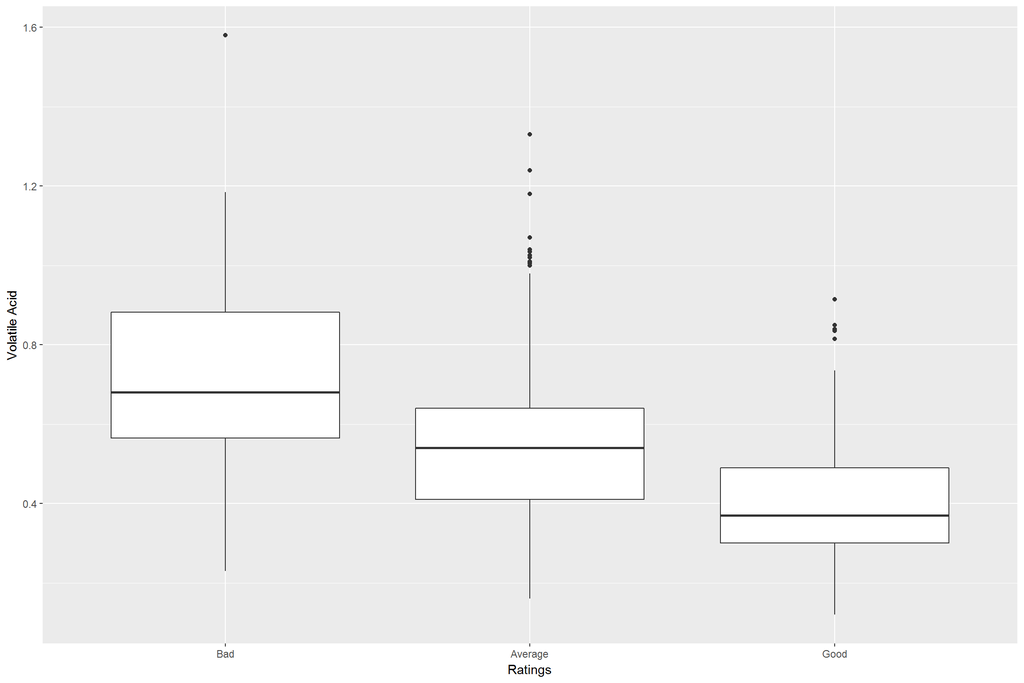

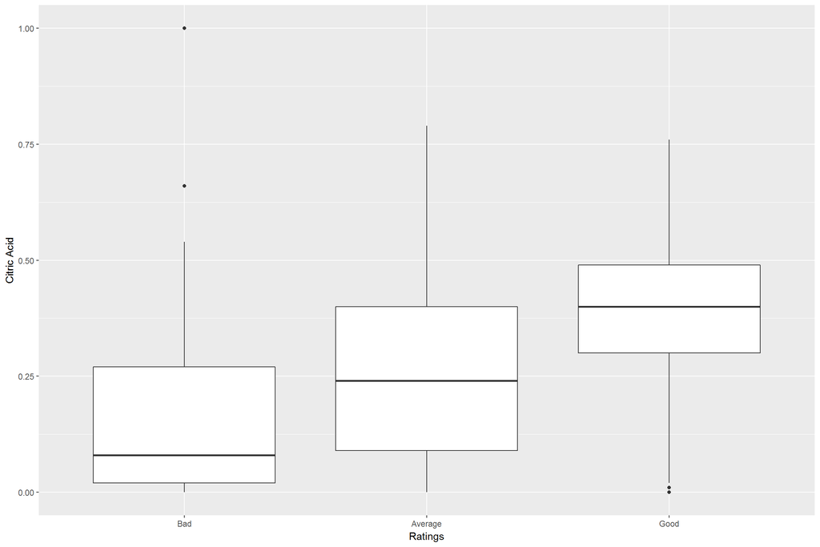

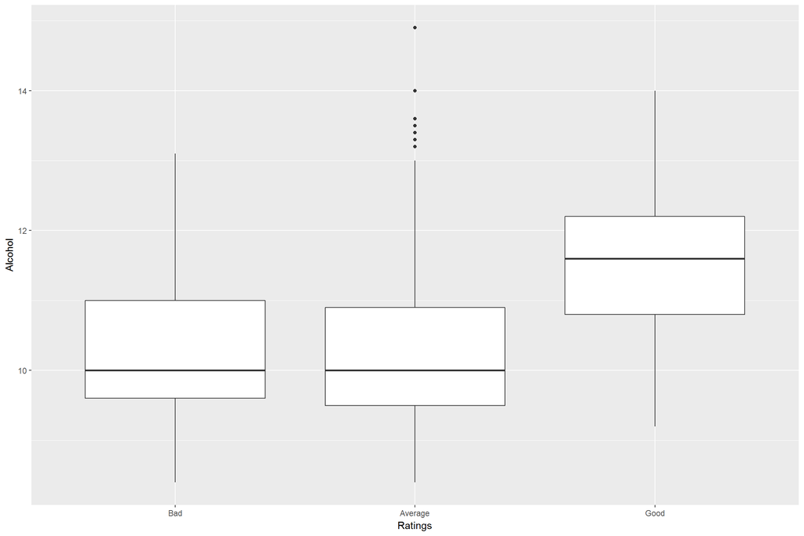

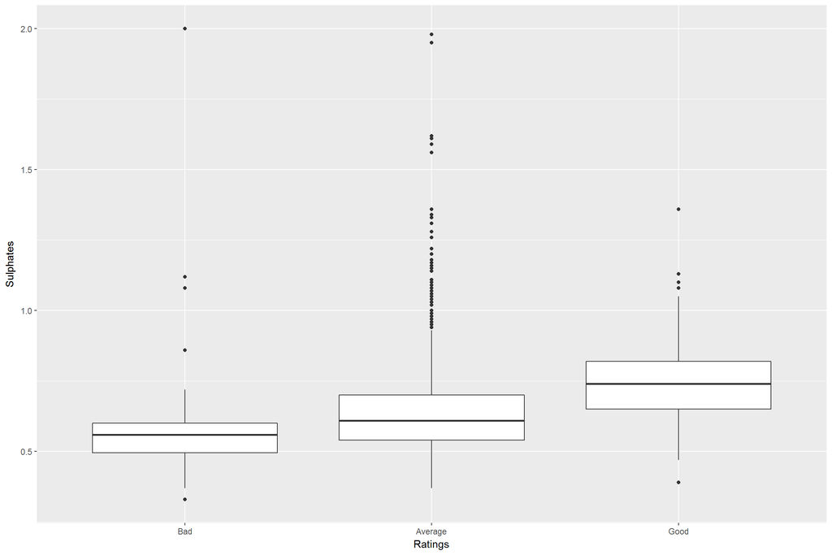

Great! The box plot supports the initial correlations that we see from the scatter plot. As we can see, Good wine has high sulphates, citric aid, alcohol and has low volatile acidity.

# Bivariate Analysis

### Talk about some of the relationships you observed in this part of the investigation. How did the feature(s) of interest vary with other features in the dataset?

The feature of interest is the quality of red wine. Looking at the correlations, alcohol, citric acid and sulphates have a positive correlation with quality of alcohol while volatile acid has a negative correlation with red wine quality.

### Did you observe any interesting relationships between the other features (not the main feature(s) of interest)?

The density of red wine is influenced by the alchohol content of the red wine while the pH is influenced by the acid content (because that is what pH is by definition)

### What was the strongest relationship you found?

The strongest relationship for red wine quality is alcohol content.

# Multivariate Plots Section

From the previous analysis, we know what variables affect the quality of the red wine. I will plot all combinations of the variables againsst quality and facet with them ratings, hopefully by doing this we can capture any special interaction between these variables for the quality of redwine.

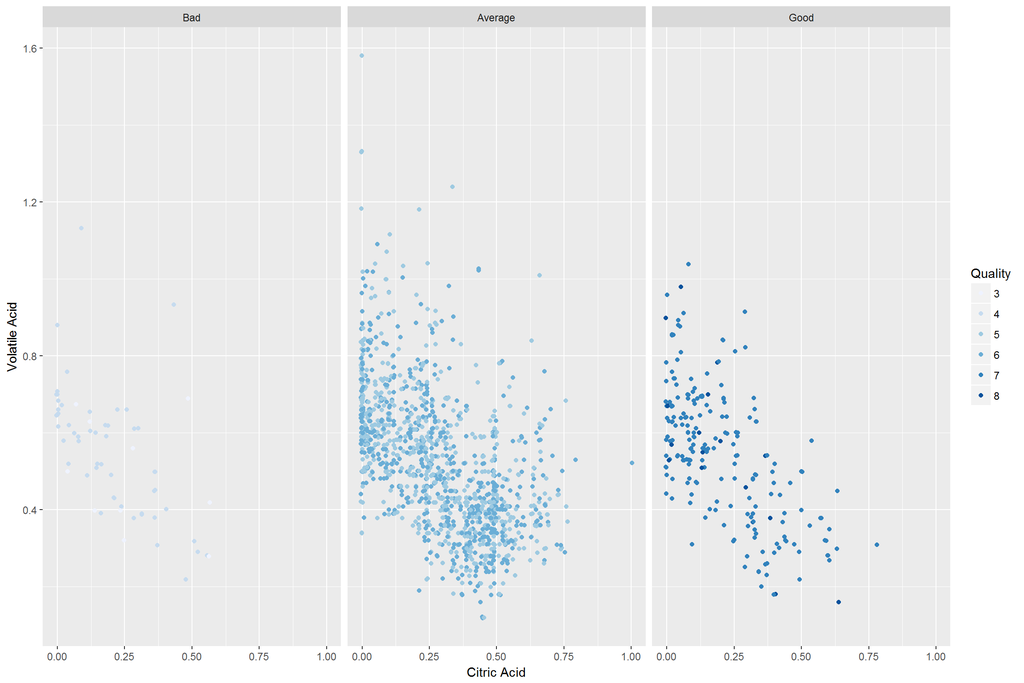

We can see that in general that red wines with low citric acid has higher volatile acid compared to red wines that has high citric acid. But it is hard to see if they have any effect of quality since the trend is similar for the three ratings and the points are very spread out.

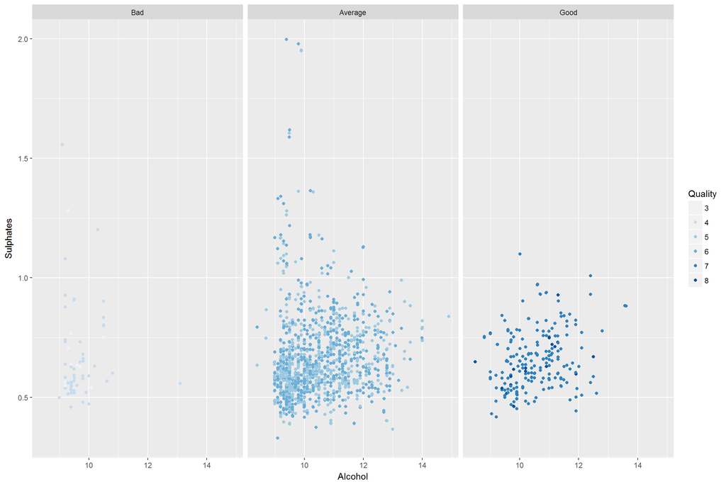

There seems to be no trend between alcohol and sulphates since all the points spreads out evenly across the ratings and it is hard to see if there is any trend in quality due to the variance of the points.

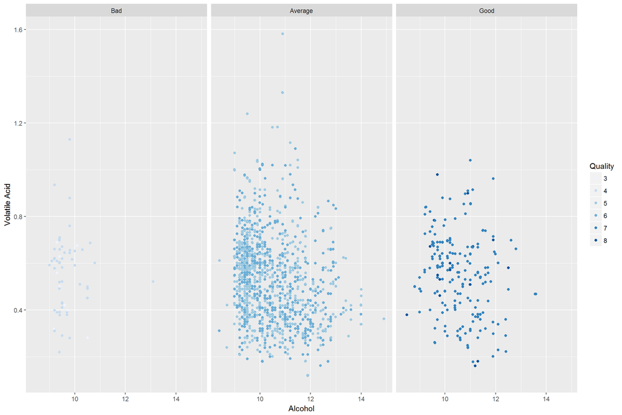

In general, red wines with low alcohol content has higher volatile acid compared to red wines that has high alcohol content. But again, it is hard to see if they have any effect of quality since the trend is similar for the three ratings and the points are very spread out.

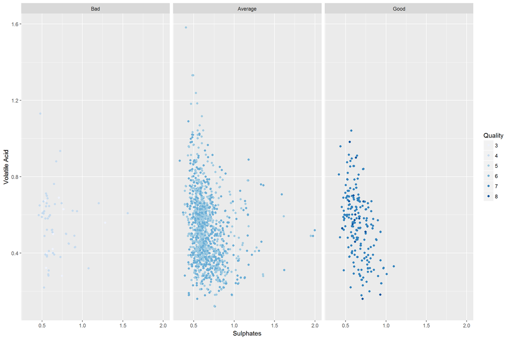

Similarly, it seems that red wines with low sulphates has higher volatile acid compared to red wines that has high sulphates and it is hard to see if they have any effect of quality since the trend is similar for the three ratings.

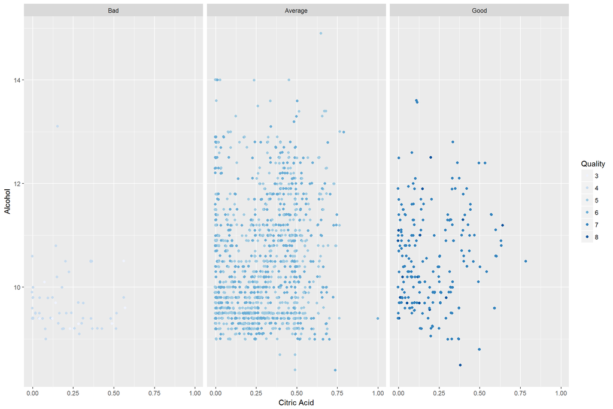

No clear trend between citric acid and alcohol and it is hard to draw any conclusions on quality as the points are highly spread out across the three ratings.

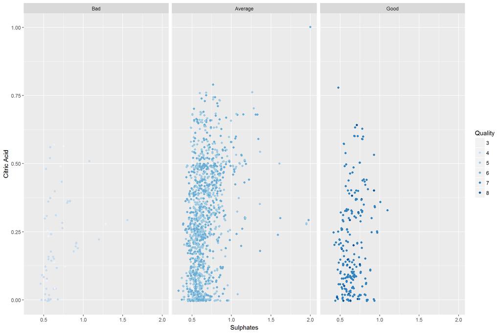

Again, it seems like the points are spread out and there is no trend between citric acid and sulphates. Also hard to see any trend with quality since the variance is present across the ratings.

It seems like we need to remove the ratings facet and add linear models to visualize the trends in quality between the variables better.

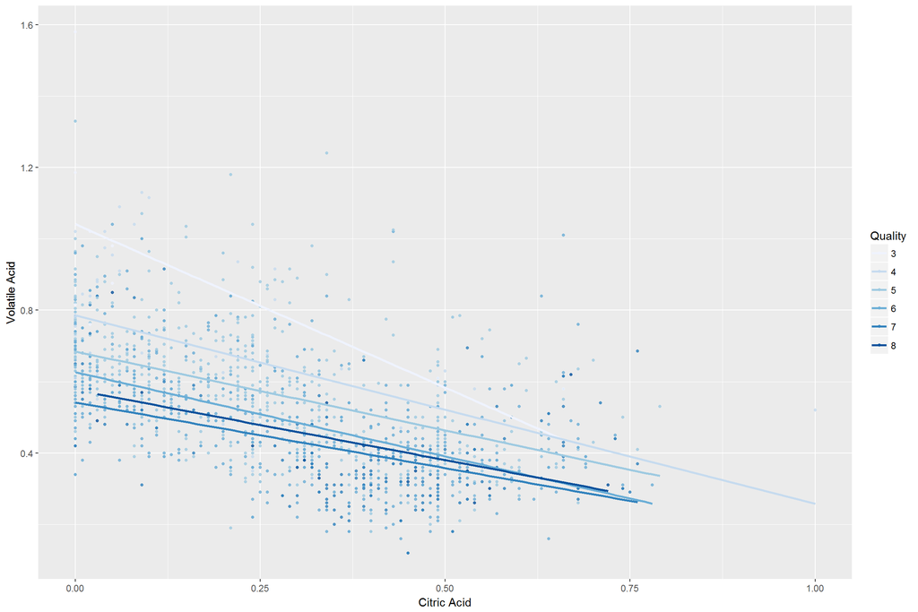

The linear model confirms what we see above, volatile acid content in red wine decreases with increasing citric acid. But we can also see that lower quality red wines has higher volatile acid content compared to higher quality red wines.

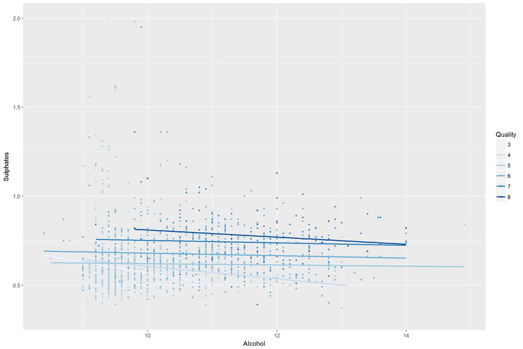

Flatness of the linear model across all quality of red wines implies that the amount of alcohol and sulphates does not correlate. But we can see that higher quality red wine has higher sulphates across all concentration of alcohol.

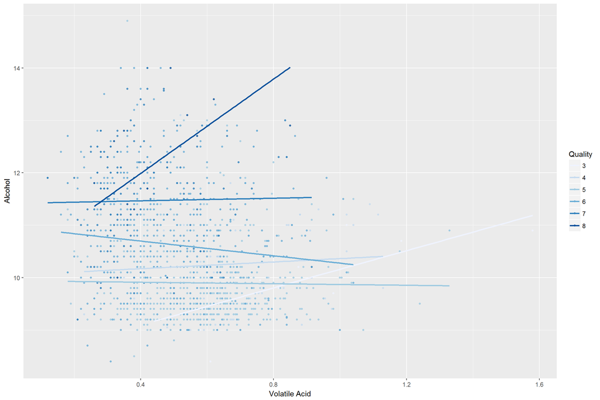

For quality 3 and 8, there seems to be higher volatile acid for higher alcohol content, but the rest seems to show that there is no relationship between amount of alcohol and volatile acid. It can be seen that higher alcohol content results in higher quality of red wine.

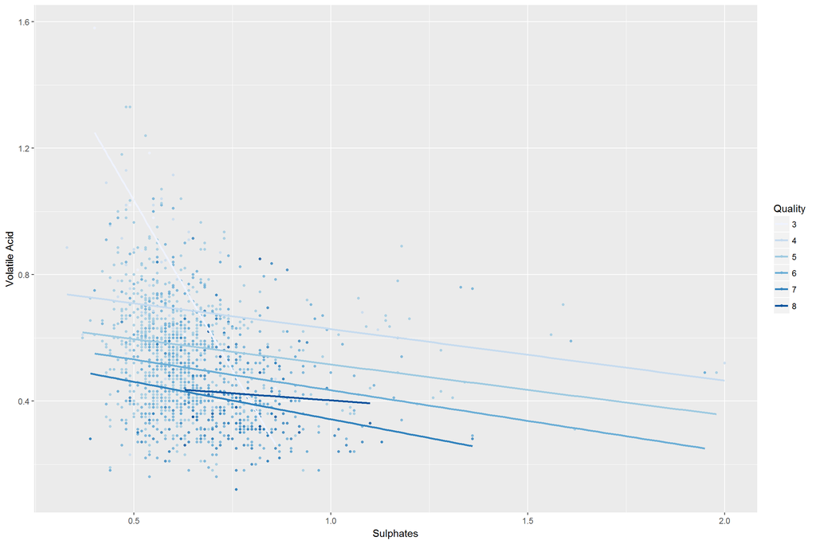

Lower quality alcohols has higher volatile acid content. There seems to be some relationship between sulphates and voltaile acid concentration where the higher the sulphates, the lower the volatile acid concentration is and it is especially true for red wine that has quality of 3.

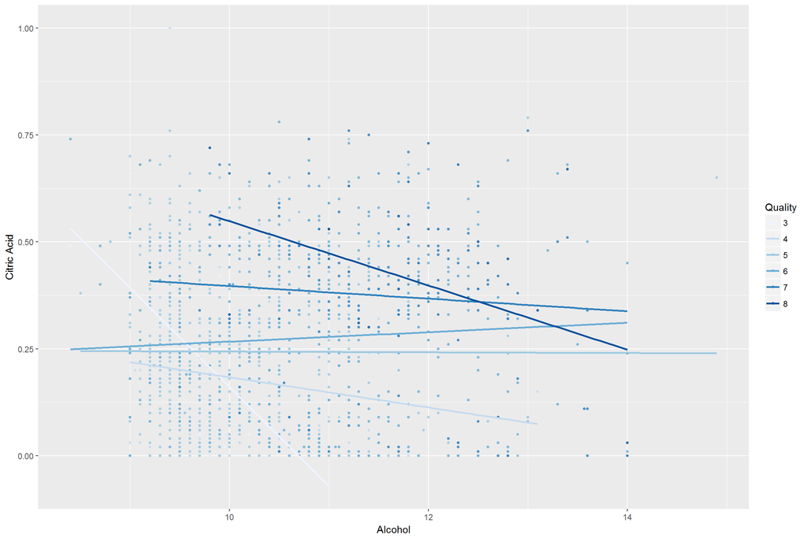

Generally, higher citric acid results in higher quality of red wine and there is no relationship between alcohol content and citric acid concentration. But, it seems for red wine that has quality of 3 and 8, the higher alcohol content the lower the citric acid concentration. This relationship is expected looking at the previous graph (alcohol and volatile acid) and knowing that volatile acid and citric acid has inverse relationship.

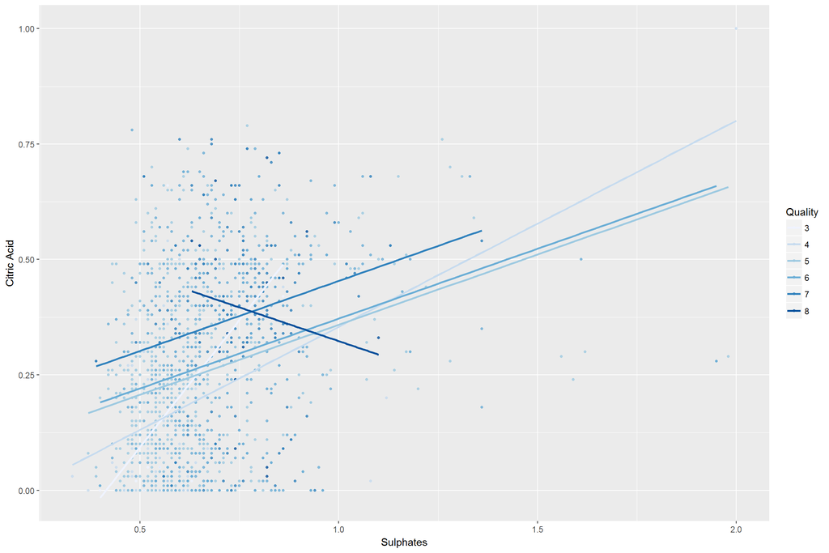

There seems to be a positive relationship between citric acid content and sulphates in red wines. Higher sulphates seems to result in higher citric acid and this relationship is more dramatic for red wine that has quality of 3.

Fitting linear models help to see the trend of the effect of the variables on the different qualities better.

Let’s look at the coefficient of the models on the variables that seems to have more effect on red wine quality. They are citric acid vs sulphates, volatile acid vs sulphates and alcohol vs sulphates shown below in that order.

```
##
## Call:
## lm(formula = quality ~ citric.acid + sulphates, data = redWine)
##
## Residuals:
##     Min      1Q  Median      3Q     Max
## -3.4107 -0.5352  0.0773  0.4960  2.4088
##
## Coefficients:
##             Estimate Std. Error t value Pr(>|t|)
## (Intercept)  4.82439    0.07751  62.244  < 2e-16 ***
## citric.acid  0.67890    0.10437   6.505 1.04e-10 ***
## sulphates    0.95369    0.11994   7.951 3.47e-15 ***
## ---
## Signif. codes:  0 '***' 0.001 '**' 0.01 '*' 0.05 '.' 0.1 ' ' 1
##
## Residual standard error: 0.772 on 1596 degrees of freedom
## Multiple R-squared:  0.0874, Adjusted R-squared:  0.08625
## F-statistic: 76.42 on 2 and 1596 DF,  p-value: < 2.2e-16
```

```
##
## Call:
## lm(formula = quality ~ volatile.acidity + sulphates, data = redWine)
##
## Residuals:
##      Min       1Q   Median       3Q      Max
## -2.92838 -0.52210 -0.01509  0.46799  2.74697
##
## Coefficients:
##                  Estimate Std. Error t value Pr(>|t|)
## (Intercept)        5.9632     0.1052  56.664  < 2e-16 ***
## volatile.acidity  -1.5726     0.1061 -14.819  < 2e-16 ***
## sulphates          0.7641     0.1121   6.816 1.32e-11 ***
## ---
## Signif. codes:  0 '***' 0.001 '**' 0.01 '*' 0.05 '.' 0.1 ' ' 1
##
## Residual standard error: 0.7333 on 1596 degrees of freedom
## Multiple R-squared:  0.1765, Adjusted R-squared:  0.1755
## F-statistic:   171 on 2 and 1596 DF,  p-value: < 2.2e-16
```

```
##
## Call:
## lm(formula = quality ~ alcohol + sulphates, data = redWine)
##
## Residuals:
##     Min      1Q  Median      3Q     Max
## -2.6685 -0.3781 -0.1005  0.4992  2.4187
##
## Coefficients:
##             Estimate Std. Error t value Pr(>|t|)
## (Intercept)  1.37497    0.17745   7.748 1.64e-14 ***
## alcohol      0.34604    0.01628  21.256  < 2e-16 ***
## sulphates    0.99409    0.10235   9.713  < 2e-16 ***
## ---
## Signif. codes:  0 '***' 0.001 '**' 0.01 '*' 0.05 '.' 0.1 ' ' 1
##
## Residual standard error: 0.6905 on 1596 degrees of freedom
## Multiple R-squared:  0.2699, Adjusted R-squared:  0.269
## F-statistic:   295 on 2 and 1596 DF,  p-value: < 2.2e-16
```

# Multivariate Analysis

### Talk about some of the relationships you observed in this part of the investigation. Were there features that strengthened each other in terms of looking at your feature(s) of interest?

After plotting all the variables that seems to have influence on quality with each other, it seems there are certain combinations of variable that exhibits clearer trends on affecting the quality of red wine while others just seem to have more of a spread.

### Were there any interesting or surprising interactions between features?

There were no surprising interaction between the features. Most of the results are expected after plotting the bivariate graphs.

### OPTIONAL: Did you create any models with your dataset? Discuss the strengths and limitations of your model.

# Final Plots and Summary

### Plot One

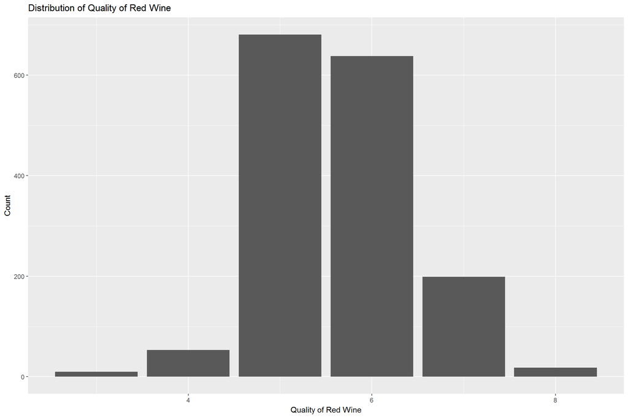

### Description One

This is the distribution of the quality of the red wines in the data set judged by experts. As you can see, most wines fall in the range of 5-6, while there are a few expectional ones and at the same time, a few poor quality ones. Interestingly, there are no red wine that is super good (quality close to 10) or super bad (quality close to 0). Also, the quality of red wine is a whole number. The distribution follows a normal distribution.

### Plot Two

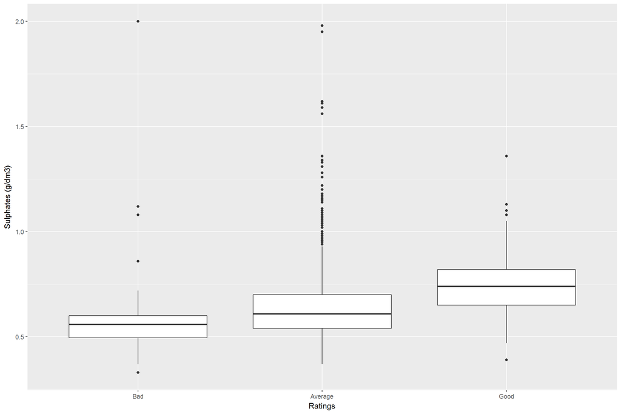

### Description Two

When you categorize the red wine quality into 3 groups: Bad (0-4), Average (5-6) and Good (7-10) and plot it against several physiochemical properties such as sulphates, citric acid content and alcohol content, you are able to see that it follows a certain trend. This plot shows quality plotted with sulphates.

In general, better quality wine has more citric acid, more alcohol, more sulphates and less volatile acid (acetic acid).

### Plot Three

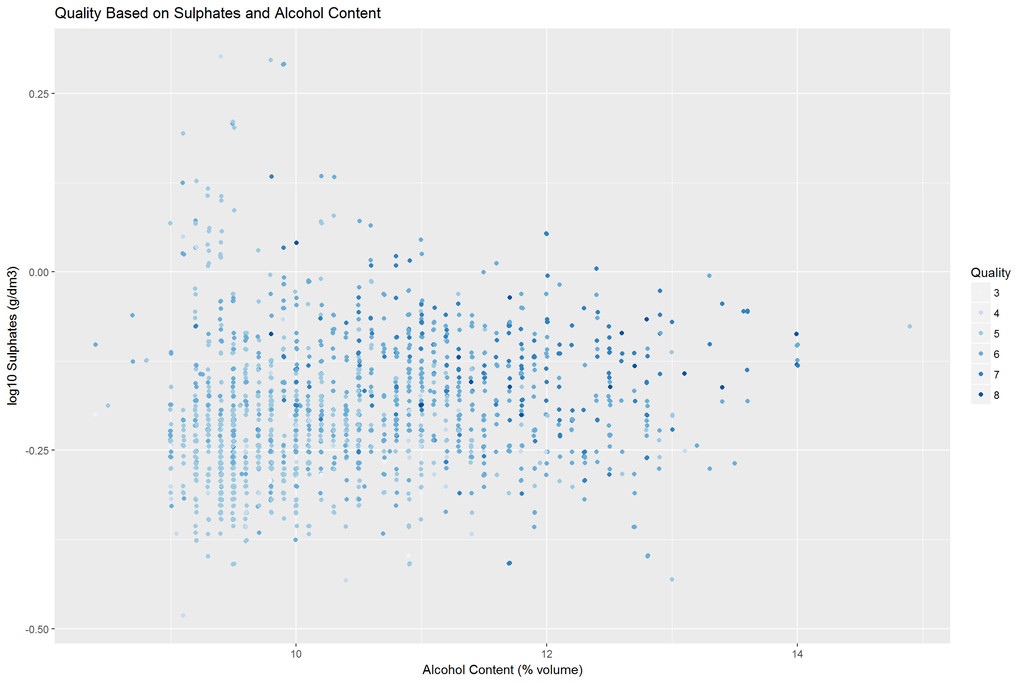

# Reflection

The red wine data set contains 1599 observations of red wines with 11 variables that describes the physical properties and chemical properties of the wine. The quality of each red wine judged by experts is also included as one of the variable in the data set. Initially, I looked at the distributions of the all the variables in the dataset, some of them exhibit normal distribution but many of them show positively skewed long tail distribution. Taking a log10 transformation to these distributions shows a normal looking distribution.

Using GGpairs function, I am able to see the correlation of all variables in a glimpse and from there decided to choose pairs that seems to have slight correlation. There are quite a few pairs that seems to have some correlation so it is quite a struggle to choose which to focus on. Since the variable of interest is quality of the red wine I decided to spend more time looking at the variables that has some correlation with the quality of the red wine. Also, by creating a new ratings variable that breaksdown the quality of red wine into three groups (Bad, Average and Good), it is easier to see the effect of each chemical properties that influences the quality of red wine. Next, I decided to plot the quality of the red wine with two variables and see if there are any surprising changes but it seems like the trends are congruent with the bivariate plots. Using a linear model, I tried to create a model for the quality of the red wine using two variables: alcohol content and sluphates content but due to the scatter of the data, I obtained a low R-squared value for the correlation.

I think the main problem is that the quality is in discrete whole numbers instead of a continuous number. For future improvement, using a more precise number for quality (such as 5.56 instead of just 6) will result in better modelling curves and analysis since all the variables (physical and chemical properties) are continuous numbers. Also, I can try other models instead of linear to fit the data since the taste and quality of red wine is a result of complicated interactions between a variety of different chemical and physical properties inside the red wine and a simple linear model will not suffice.